# writeup

Kelly Chen

9/25/2021

## Introduction

The world series is a best-of-7 match-up between the champions of the American and National Leagues of Major League Baseball. This document is to analyze and explain the probability calculations related to world series.

Suppose that the Braves and the Yankees are teams competing in the World Series. Suppose that in any given game, the probability that the Braves win is PB and the probability that the Yankees win is P= 1 − PB.

## Question 1

What is the probability that the Braves win the World Series given that P=0.55?

```r
library(ggplot2)
library(dplyr)
```

There are 7 teams in the game, so the total match Braves needed is 7 games, and to win the world series, Braves needs to win at least 4 games.

since pbinom produces the at most 3 games winning probability, we need to subtract that probability to get the result of winning at least 4 games probability.

```r
1-pbinom(3,7,0.55)
```

```
## [1] 0.6082878
```

Answer: The probability that the Braves win the World Series given P=0.55 is 0.6082878.This is a relatively high win rate, which means that on average the Braves has a high chance of winning the world series given that they have 0.55 win rate for each match in the world series.

## Question 2

What is the probability that the Braves win the World Series given that P=x?

Assume p is a random probability between 0-1. Here we take 51 values of P to run the simulation to test the probability of Braves wins the world series.

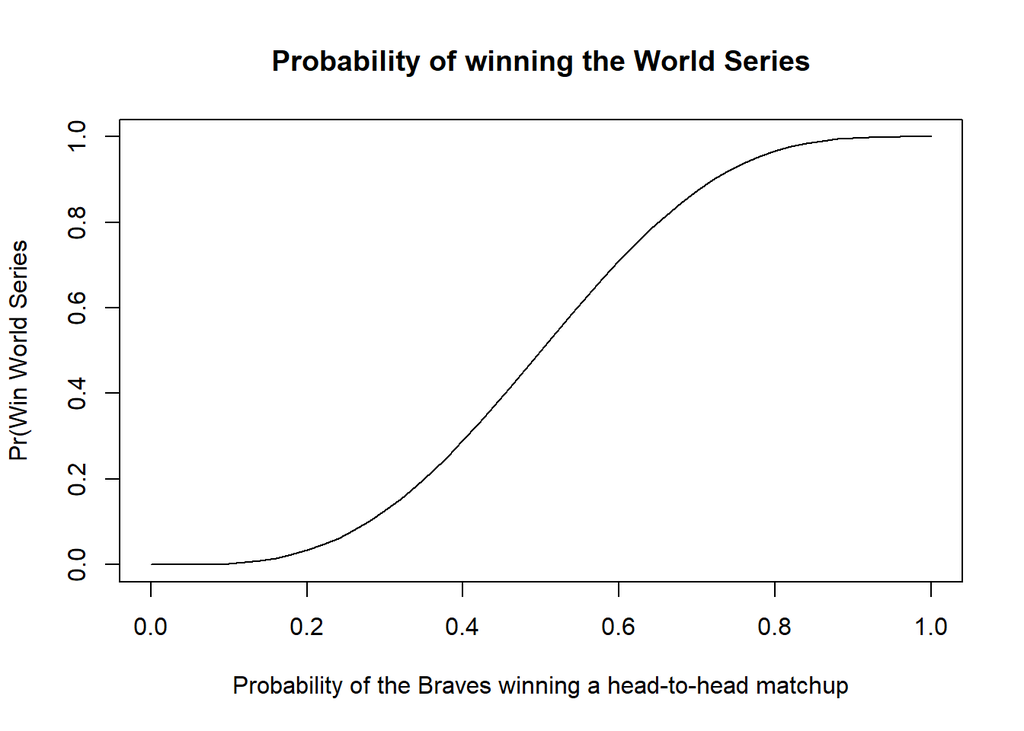

```r
p2<-seq(0,1,0.02)
p_win<-rep(NA,100)

#Simulation
for (i in seq_along(p2)){
  p_win[i]<- 1-pbinom(3,7,p2[i])
}
#remove na values in the p_win
p_win<-na.omit(p_win)

#plot p2 and p_win
plot(p2,p_win,xlab='Probability of the Braves winning a head-to-head matchup',ylab='Pr(Win World Series',type='l',main='Probability of winning the World Series')
```

From the plot we could see the probability that the Braves win the World Series given that P=x, so the p is a random variable we produced from simulation. We could see as x increases, the winning probability of the Braves also increases.

## Question 3

Suppose one could change the World Series to be best-of-9 or some other best-of-X series. What is the shortest series length so that P(Braves win World Series|P=.55)≥0.8

```r
best_x<-seq(1,999,2)
p_win_1<-rep(NA,100)

#simulation
for (i in seq_along(best_x)){
  best_cal<-ceiling(best_x[i]/2)
  p_win_1[i]<- 1-pbinom(best_cal-1,best_x[i],0.55)
}

#check p_win_1 value
p_win_1<-na.omit(p_win_1)

#create data frame for the two variables
best_data<-data.frame(number_of_series=best_x,win_probability=p_win_1)

#filter winning probability larger than 0.8
best_data %>%
  filter(win_probability>=0.8) %>%
  filter(win_probability==min(win_probability))
```

```
##   number_of_series win_probability
## 1               71       0.8017017
```

Answer: The shortest number of series needed is 71. This means that if the world series is to be best-of-71 games, then the Braves could have a winrate higher than 0.8 given that their winrate for each game is 0.55.

## Question 4

What is the shortest series length so that P(Braves win World Series|P=x)≥0.8? This will be a figure (see below) with PB on the x-axis and series length is the y-axis.

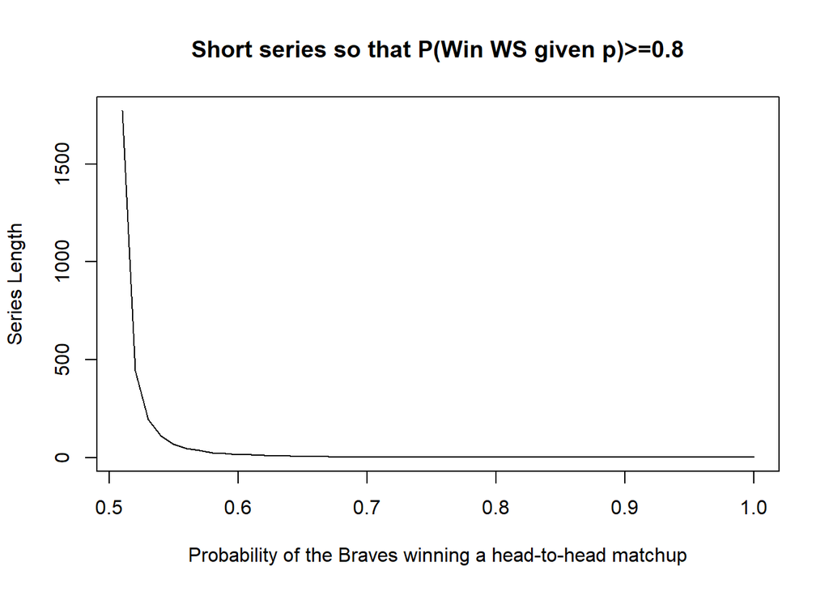

```r
#set the x value for best of x series, we set the maximum value of x to 100.

best_x<-seq(3,9999,2)
p_x<-seq(0.51,1,0.01)
series_length<-rep(NA,length(p_x))


#simulation
#Each time when we run the simulation, we keep a record of shortest series length for each Pb.

for (i in seq_along(p_x)){
  for (j in seq_along(best_x)){
  best_cal<-ceiling(best_x[j]/2)
  p_win_1<- 1-(pbinom(best_cal-1,best_x[j],p_x[i]))
  if (p_win_1>=0.8){
    shortest<-best_x[j]
    break}
  }
  series_length[i]<-shortest}

#Remove na values of series_length
series_length<-na.omit(series_length)

#Plot the relationship between Pb and shortest series length.
plot(x=p_x,y=series_length,type='l',xlab='Probability of the Braves winning a head-to-head matchup',ylab='Series Length',main='Short series so that P(Win WS given p)>=0.8')
```

From the plot we could see that the shortest series length needed so that P(Braves win World Series|P=x)≥0.8 is when p is over approximately 0.55, after 0.55 the less the series length needed for the Braves to win.

## Question 5

Calculate P(Pb=0.55|Braves win World Series in 7 games) under the assumption that either Pb=0.55 or Pb=0.45. Explain your solution.

We would utilize Bayes rule and the law of total probability to calculate the problem. We know that **P(A|B)=P(B|A)*P(A)/P(B)** In this problem, we set P(A) as the probability of Pb=0.55, which is P(Pb=0.55). We set P(B) as the probability of Braves win world series in 7 games.

Since Pb is either 0.55 or 0.45, so the **P(A)=P(Pb=0.55)=0.5**. Since there are only two conditions where Pb=0.45 or Pb=0.55, so the total probability of winning the world series should be an average of the two condition.

```r
#Calculate the winning probability of Braves when situation is either 0.45 or 0.55
p_win_0.55<-dbinom(4,7,0.55)
p_win_0.45<-dbinom(4,7,0.45)

#The average of winning probability assume either situation happens is 1/2.
p_total_win<-(p_win_0.55+p_win_0.45)/2
p_total_win
```

```
## [1] 0.2653161
```

From question 1, we know that **P(B|A)=P(winning the world series|p=0.55)=p_win_0.55**. P(B) Here is the average of two situations that Braves win 4 lose 3 games probability, which is p_total_win.

```r
#Assume the probability of either 0.55 or 0.45 is 1/2.
p_a<-0.5
p_b<-0.5

#According to Bayes Rule, calculate p_final
p_final<-p_win_0.55*p_a/p_total_win
p_final
```

```
## [1] 0.55
```

Answer: The probability for the problem is 0.55. This means that if the Braves has a winrate of either 0.55 or 0.45, and the probability of each situation happens is 0.5, then given that the Braves win World Series in 7 games, the winrate of the Braves in each game is 0.55.